# High School Seniors t Test

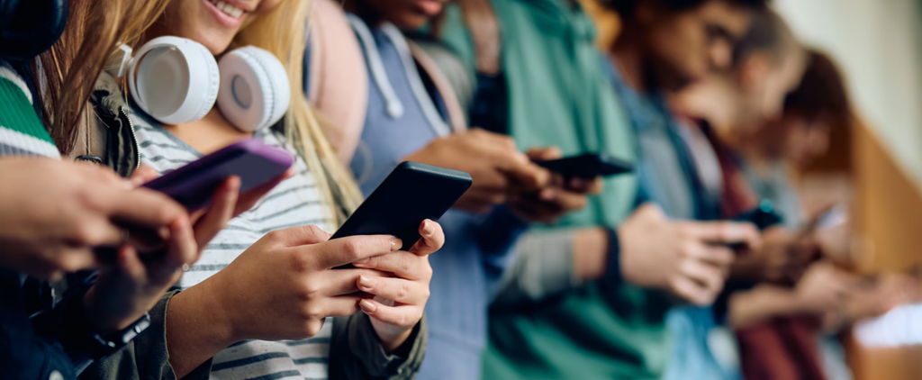

```r
library(tidyverse)
library(DT)
library(pander)
library(readr)
library(mosaic)
library(ggthemes)
library(car)

HSS <- read_csv("C://Users/Alex/Documents/GitHub/Portfolio/AB_TESTS/HighSchoolSeniors.csv")
```

## Background

In the US Census at High Schools 2020, there was a survey given to each student to fill out and gather information about the statistics of students’ lives and personal information, such as Gender, the number of texts received the day before, height, and many other details. Which sets the stage to answer the stereotypical question:

## Do Females tend to receive more text messages on average than Males in high school?

$$H_0: \mu femals = \mu males$$

$$H_a: \mu females > \mu males$$

The significance level will be tested at a 0.05 alpha(α).

## Analysis

After filtering data by gender groups and text received below 250 to obtain a reasonable sample, the graph displays that females do have a higher median number of texts received than males, implying that the group sample of females doesn’t rely on outliers receiving hundreds of messages to represent the overall number of texts received. Although the distributions of each gender aren’t normal in the qqPlot because many data-points aren’t normal (overlapping the blue range), the sample size of each group is above 30, representing an approximately normal sampling to perform test statistics due to the Central Limit Theorem. But, in terms of means, is the female mean significantly bigger than the male means?

```r
HSS_clean <- HSS %>% filter(Gender %in% c("Female","Male"),
                    Text_Messages_Received_Yesterday < 250)
```

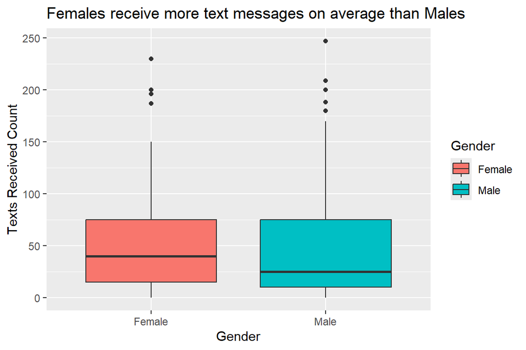

```r
ggplot(HSS_clean, mapping = aes(x = Gender, y = Text_Messages_Received_Yesterday, fill = Gender)) + geom_boxplot() +
  scale_y_continuous(breaks = seq(0,500,50)) +
  labs(title = "Females receive more text messages on average than Males",
       y = "Texts Received Count")
```

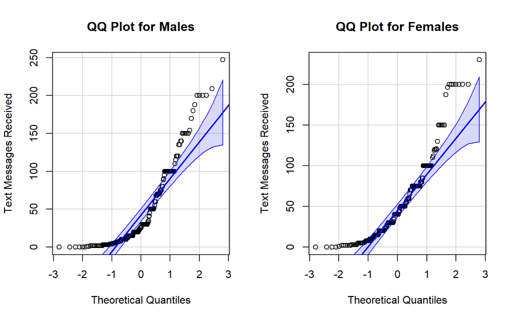

```r
par(mfrow = c(1, 2))
# QQ plot for males
qqPlot(HSS_clean$Text_Messages_Received_Yesterday[HSS_clean$Gender == "Male"],
       main = "QQ Plot for Males",
       xlab = "Theoretical Quantiles",
       ylab = "Text Messages Received",
       id = FALSE)
qqPlot(HSS_clean$Text_Messages_Received_Yesterday[HSS_clean$Gender == "Female"],
       main = "QQ Plot for Females",
       xlab = "Theoretical Quantiles",
       ylab = "Text Messages Received",
       id = FALSE)
```

```r
# QQ plot for females
```

## Interpretation

The QQPlots display the normality of data, with the purpose of showcasing wether the data is reliable to make conclusions to avoid biased or skewed data. By the dots within the blue range being represented as “normal” whereas the opposite applies to values outside the range. However, since we have more than 30 subjects for each group, the sampling distribution of the sample means can be assumed to be approximately normal to proceed with the a/b test.

After performing a t-test, we can appreciate that although it is unlikely that the female means are the same as the males with a p-value of 0.1139, the p-value isn’t significant at a 0.05 alpha level. Implying that we cannot reject the null, or conclude that females tend to receive more text messages on average than males in high school.

```r
Males <- HSS_clean %>% filter(Gender %in% "Male")
Females <- HSS_clean %>% filter(Gender %in% "Female")

pander(t.test(Females$Text_Messages_Received_Yesterday,
       Males$Text_Messages_Received_Yesterday,
       alternative = "greater"))
```

Welch Two Sample t-test: `Females$Text_Messages_Received_Yesterday` and `Males$Text_Messages_Received_Yesterday`

| Test statistic | df | P value | Alternative hypothesis | mean of x | mean of y |
| --- | --- | --- | --- | --- | --- |
| 1.208 | 393 | 0.1139 | greater | 54.44 | 48.15 |

```r
pander(favstats(HSS_clean$Text_Messages_Received_Yesterday ~ HSS_clean$Gender))
```

| HSS_clean$Gender | min | Q1 | median | Q3 | max | mean | sd | n | missing |
| --- | --- | --- | --- | --- | --- | --- | --- | --- | --- |
| Female | 0 | 15 | 40 | 75 | 230 | 54.44 | 50.55 | 194 | 0 |
| Male | 0 | 10 | 25 | 75 | 247 | 48.15 | 52.9 | 201 | 0 |